# Final Project

CLAUDE SHANNON

2024-01-30

## Introduction

The exploration of health-related datasets has emerged as an important endeavor in advancing public health research. This paper aims to explore the Behavioral Risk Factor Surveillance System (BRFSS) dataset, which conducts annual telephone surveys to collect data on the health status of U.S. to detect possible patters that allow us to detect if a patient is at risk to have a heart attack. This research bears significance in contributing to early detection and risk assessment and influencing targeted healthcare interventions.

The original dataset consist of `445132` observations with `40` variables of categorical or numerical nature:

- `State`: State of residence [chr]
- `Gender`: Gender of Resident [chr: Female, Male]
- `GeneralHealth`: Would you say that in general your health is: [chr: Excellent, Very good, Good, Fair, Poor]
- `PhysicalHealthDays`: Now thinking about your physical health, which includes physical illness and injury, for how many days during the past 30 days was your physical health not good? [num: 0, 1, …, 30]
- `MentalHealthDays`: Now thinking about your mental health, which includes stress, depression, and problems with emotions, for how many days during the past 30 days was your mental health not good? [num: 0, 1, …, 30]
- `LastCheckupTime`: About how long has it been since you last visited a doctor for a routine checkup? [chr: Within the past year (less than 12 months ago), Within past 2 years (1 year but less than 2 years ago), Within past 5 years (2 years but less than 5 years ago)]
- `PhysicalActivities`: During the past month, other than your regular job, did you participate in any physical activities or exercises such as running, calisthenics, golf, gardening, or walking for exercise? [chr: No, Yes]
- `SleepHours`: On average, how many hours of sleep do you get in a 24-hour period? [num: 0, 1, …, 24]
- `RemovedTeeth`: Not including teeth lost for injury or orthodontics, how many of your permanent teeth have been removed because of tooth decay or gum disease? [chr: All, 6 or more (but not all), 1 to 5, None of them]
- `HadHeartAttack`: (Ever been told) you had a heart attack, also called a myocardial infarction? [chr: No, Yes]
- `HadAngina`: (Ever been told) you had angina or coronary heart disease? [chr: No, Yes]
- `HadStroke`: (Ever been told) you had a stroke? [chr: No, Yes]
- `HadAsthma`: (Ever been told) you had asthma? [chr: No, Yes]
- `HadSkinCancer`: (Ever been told) you had skin cancer that is not melanoma? [chr: No, Yes]
- `HadCOPD`: (Ever been told) you had C.O.P.D. (chronic obstructive pulmonary disease), emphysema or chronic bronchitis? [chr: No, Yes]
- `HadDepressiveDisorder`: (Ever been told) you had a depressive disorder (including depression, major depression, dysthymia, or minor depression)? [chr: No, Yes]
- `HadKidneyDisease`: Not including kidney stones, bladder infection or incontinence, were you ever told you had kidney disease? [chr: No, Yes]
- `HadArthritis`: (Ever been told) you had some form of arthritis, rheumatoid arthritis, gout, lupus, or fibromyalgia? (Arthritis diagnoses include: rheumatism, polymyalgia rheumatica; osteoarthritis (not osteporosis); tendonitis, bursitis, bunion, tennis elbow; carpal tunnel syndrome, tarsal tunnel syndrome; joint infection, etc.) [chr: No, Yes]
- `HadDiabetes`: (Ever been told) you had diabetes? [chr: No, No only pre-diabetes or borderline diabetes, Yes, Yes but only during pregnancy (female)]
- `DeafOrHardOfHearing`: Are you deaf or do you have serious difficulty hearing? [chr: No, Yes]
- `BlindOrVisionDifficulty`: Are you blind or do you have serious difficulty seeing, even when wearing glasses? [chr: No, Yes]
- `DifficultyConcentrating`: Because of a physical, mental, or emotional condition, do you have serious difficulty concentrating, remembering, or making decisions? [chr: No, Yes]
- `DifficultyDressingBathing`: Do you have difficulty dressing or bathing? [chr: No, Yes]
- `DifficultyErrands`: Because of a physical, mental, or emotional condition, do you have difficulty doing errands alone such as visiting a doctor´s office or shopping? [chr: No, Yes]
- `SmokerStatus`: Four-level smoker status [chr: Everyday smoker, Someday smoker, Former smoker, Never smoked]
- `ECigarretteUsage`: Would you say you have never used e-cigarettes or other electronic vaping products in your entire life or now use them every day, use them some days, or used them in the past but do not currently use them at all? [chr: Use them every day, Use them some days, Not at all (right now), Never used e-cigarettes in my entire life]
- `ChestScan`: Have you ever had a CT or CAT scan of your chest area? [chr: No, Yes]
- `RaceEthnicityCategory`: Five-level race/ethnicity category [chr: White only Non-Hispanic, Black only Non-Hispanic, Hispanic, Multiracial Non-Hispanic, Other race only Non-Hispanic]
- `AgeCategory`: Fourteen-level age category [chr: 50 to 54, 55 to 59, 60 to 64, 65 to 69, 70 o 74, 75 to 79, 80 or older]
- `HeightInMeters`: Reported height in meters [num]
- `WeightInKilograms`: Reported weight in kilograms [num]
- `BMI`: Body Mass Index [num]
- `AlcoholDrinkers`: Adults who reported having had at least one drink of alcohol in the past 30 days. [chr: No, Yes]
- `HIVTesting`: Adults who have ever been tested for HIV [chr: No, Yes]
- `FluVaxLast12`: During the past 12 months, have you had either flu vaccine that was sprayed in your nose or flu shot injected into your arm? [chr: No, Yes]
- `PneumoVaxEver`: Have you ever had a pneumonia shot also known as a pneumococcal vaccine? [chr: No, Yes]
- `TetanusLast10Tday`: Have you received a tetanus shot in the past 10 years? Was this Tdap, the tetanus shot that also has pertussis or whooping cough vaccine?[chr: Yes received Tdap, Yes received tetanus shot but not sure what type,Yes received tetanus shot but not Tdap, No did not receive any tetanus shot in the past 10 years]
- `HighRiskLastYear`: You have injected any drug other than those prescribed for you in the past year. You have been treated for a sexually transmitted disease or STD in the past year. You have given or received money or drugs in exchange for sex in the past year. [chr: No, Yes]
- `CovidPos`: Has a doctor, nurse, or other health professional ever told you that you tested positive for COVID 19? [chr: No, Tested positive using home test, Yes]

Formally, we aim to address whether a patient will experience a heart attack by employing an array of predictive models and selecting the most frequent result. Furthermore, we’ll provide the features that most contribute to this prediction analyzing some of the used models.

For it, we’ll need to clean the data set to best fit our predictive models by:

- Reducing the amount of features
- Apply feature engineering
- Merge variables that present high colinearity
- Replace missing data

## Helpers

Here we define a set of functions that might prove useful to increase the readability of the code

This function will be used to train and evaluate different models.

```r
model_accuracy <- function(model, train, test, characteristic) {
  fitted_model <- model |>
    fit(as.formula(paste(characteristic, "~ .")), data = train) # nolint

  pred <- fitted_model |>
    predict(test) |>
    pull(.pred_class) # nolint

  results <- test |>
    mutate(predictions = pred) |>
    metrics(truth = !!as.name(characteristic), estimate = predictions) |> # nolint
    filter(.metric %in% c("accuracy", "kap")) |> # nolint
    pivot_wider(names_from = .metric, values_from = .estimate) |> # nolint
    select(accuracy, kap) # nolint

  return(list("model" = fitted_model, "metrics" = as.data.frame(results)))
}
```

Function used to obtain the statistics of a model.

```r
model_statistics <- function(num_samples, target_variable, dataframe) {
  df2 <- dataframe

  # Sample non-NA indices
  non_na_indices <- which(!is.na(df2[[target_variable]]))
  sample_indices <- sample(non_na_indices, num_samples)

  df2[[target_variable]][sample_indices] <- NA

  # Build model
  model_formula <- formula(paste(target_variable, "~ ."))
  weight_model <- rpart(model_formula, data = df2, method = "anova")

  # Predict for NA values
  df2[[target_variable]][is.na(df2[[target_variable]])] <-
    predict(weight_model, newdata = df2[is.na(df2[[target_variable]]), ])

  # Actual values for comparison
  actual_values <- dataframe[[target_variable]][sample_indices]

  # Calculate accuracy and standard deviation
  accuracy <- 1 - sum((df2[[target_variable]][sample_indices] - actual_values)^2) / sum((actual_values - mean(actual_values))^2)
  std_deviation <- sd(df2[[target_variable]][sample_indices] - actual_values)

  # Return results
  return(tibble(accuracy = accuracy, std_deviation = std_deviation))
}
```

Function to plot pie plots

```r
plot_pie_freq <- function(variable, plot_name) {
  data <- data.frame(table(variable))

  color_palette <- pals::stepped3(n = length(unique(variable)))
  ggplot(data, aes(x = "", y = Freq, fill = variable)) +
    geom_bar(stat = "identity", width = 1) +
    geom_text(
      aes(x = 1.6, label = sprintf("%.1f%%", Freq / sum(Freq) * 100)),
      position = position_stack(vjust = 0.5),
      size = 4
    ) +
    coord_polar(theta = "y") +
    labs(title = plot_name) +
    scale_fill_manual(values = color_palette) +
    theme_void() +
    theme(
      axis.title.x = element_blank(),
      axis.title.y = element_blank(),
      plot.title = element_text(hjust = 0.5)
    )
}
```

Functions to apply clustering.

```r
perform_hclust <- function(data, method, num_clusters) {
  hc <- hclust(dist(data), method = method)
  hc <- cutree(hc, k = num_clusters)
  return(list(
    method = method,
    num_clusters = num_clusters,
    silhouette = sum(data.frame(silhouette(hc, dist(data)))$sil_width)
  ))
}

plot_hclust <- function(data, method, num_clusters, plot_name) {
  hc <- as.dendrogram(hclust(dist(data), method = method))
  hc <- color_branches(hc, k = num_clusters)

  fviz_dend(
    hc,
    main = plot_name,
    show_labels = FALSE
  ) +
    theme( # nolint
      plot.title = element_text(size = 14, hjust = 0.5), # nolint
    )
}

make_hclust <- function(variable, plot_name) {
  parameters <- expand.grid(
    method = c(
      "single", "complete", "average", "mcquitty", "median", "centroid"
    )
  )

  hclust_metrics <- bind_rows(
    pmap(parameters, ~ perform_hclust(variable, ..1, num_clusters = 3))
  )

  best_result <- hclust_metrics[which.max(hclust_metrics$silhouette), ]


  plot_hclust(variable, best_result$method, best_result$num_clusters, plot_name)

  return(cutree(
    hclust(dist(variable), method = best_result$method),
    k = best_result$num_clusters
  ))
}
```

A fine tuned implementation of the training loop

```r
apply_model_training <- function(name, model, train, test, characteristic) {
  cat("[DOING]", name, "\n")
  fitted_model <- model |>
    fit(as.formula(paste(characteristic, "~ .")), data = train) # nolint

  pred <- fitted_model |>
    predict(test) |>
    pull(.pred_class) # nolint

  results <- test |>
    mutate(predictions = pred) |> # nolint
    metrics(truth = !!as.name(characteristic), estimate = predictions) |> # nolint
    filter(.metric %in% c("accuracy", "kap")) |> # nolint
    pivot_wider(names_from = .metric, values_from = .estimate) |> # nolint
    select(accuracy, kap) # nolint

  return(list(
    "name" = name,
    "model" = fitted_model,
    "metrics" = as.data.frame(results)
  ))
}
```

An exhaustive apriori helper that permutates the list of parameters and applies apriori on each of them, allowing the exploration of the hyperparameters domain

```r
run_apriori_with_loop <- function(transactions, supp_values, conf_values, minlen_values, verbose = FALSE) {
  result_df <- data.frame()

  for (supp_val in supp_values) {
    for (conf_val in conf_values) {
      for (minlen_val in minlen_values) {
        if (verbose) {
          cat("[INFO] Doing...", "Support:", supp_val, "Confidence:", conf_val, "MinLength:", minlen_val, "\n")
        }
        rules <- apriori(
          transactions,
          parameter = list(
            supp = supp_val,
            conf = conf_val,
            minlen = minlen_val
          ),
          appearance = list(
            rhs = c("HadHeartAttack=1", "HadHeartAttack=0")
          ),
          control = list(verbose = FALSE)
        )

        if (length(rules) == 0) {
          next
        }

        result_df <- rbind(
          result_df,
          data.frame(
            Support = supp_val,
            Confidence = conf_val,
            MinLength = minlen_val,
            Redundant_Rules = length(rules[is.redundant(rules)]),
            Non_Redundant_Rules = length(rules[!is.redundant(rules)])
          )
        )
      }
    }
  }

  return(result_df)
}
```

## Setup

```r
library(dplyr)
library(ggplot2)
library(here)
library(purrr)
library(rpart)
library(statebins)
library(tidygeocoder)
library(leaflet)
library(gridExtra)
library(GGally)
library(stringr)
library(pals)
library(cluster)
library(factoextra)
library(tidymodels)
library(caret)
library(glue)
library(dbscan) # Density based cluster
library(patchwork) # Plot composer
library(dendextend) # Color dedongram by cluster
library(arules)
```

```r
df <- read.csv(here("data", "heart_data.csv"))

df[df == ""] <- NA
df <- df |> mutate(across(where(is.character), as.factor))
```

```r
str(df)
```

```
## 'data.frame':    445132 obs. of  40 variables:
##  $ State                    : Factor w/ 54 levels "Alabama","Alaska",..: 1 1 1 1 1 1 1 1 1 1 ...
##  $ Gender                   : Factor w/ 2 levels "Female","Male": 1 1 1 1 1 2 1 1 1 1 ...
##  $ GeneralHealth            : Factor w/ 5 levels "Excellent","Fair",..: 5 1 5 1 2 4 5 3 3 3 ...
##  $ PhysicalHealthDays       : int  0 0 2 0 2 1 0 0 0 1 ...
##  $ MentalHealthDays         : int  0 0 3 0 0 0 0 0 0 0 ...
##  $ LastCheckupTime          : Factor w/ 4 levels "5 or more years ago",..: 4 NA 4 4 4 4 4 4 4 4 ...
##  $ PhysicalActivities       : Factor w/ 2 levels "No","Yes": 1 1 2 2 2 1 2 1 2 2 ...
##  $ SleepHours               : int  8 6 5 7 9 7 7 8 6 7 ...
##  $ RemovedTeeth             : Factor w/ 4 levels "1 to 5","6 or more, but not all",..: NA NA NA NA NA NA NA NA NA NA ...
##  $ HadHeartAttack           : Factor w/ 2 levels "No","Yes": 1 1 1 1 1 2 1 1 1 1 ...
##  $ HadAngina                : Factor w/ 2 levels "No","Yes": 1 1 1 1 1 1 1 1 1 1 ...
##  $ HadStroke                : Factor w/ 2 levels "No","Yes": 1 1 1 1 1 2 1 1 1 1 ...
##  $ HadAsthma                : Factor w/ 2 levels "No","Yes": 1 1 1 2 1 1 1 1 1 1 ...
##  $ HadSkinCancer            : Factor w/ 2 levels "No","Yes": 1 2 2 1 1 1 1 1 2 1 ...
```

[output cut: 26 more lines]

```r
summary(df)
```

```
##         State           Gender         GeneralHealth    PhysicalHealthDays
##  Washington: 26152   Female:235893   Excellent: 71878   Min.   : 0.000
##  New York  : 17800   Male  :209239   Fair     : 60273   1st Qu.: 0.000
##  Minnesota : 16821                   Good     :143598   Median : 0.000
##  Ohio      : 16487                   Poor     : 19741   Mean   : 4.348
##  Maryland  : 16418                   Very good:148444   3rd Qu.: 3.000
##  Texas     : 14245                   NA's     :  1198   Max.   :30.000
##  (Other)   :337209                                      NA's   :10927
##  MentalHealthDays
##  Min.   : 0.000
##  1st Qu.: 0.000
##  Median : 0.000
##  Mean   : 4.383
##  3rd Qu.: 5.000
##  Max.   :30.000
##  NA's   :9067
##                                                 LastCheckupTime
##  5 or more years ago                                    : 19079
##  Within past 2 years (1 year but less than 2 years ago) : 41919
##  Within past 5 years (2 years but less than 5 years ago): 24882
##  Within past year (anytime less than 12 months ago)     :350944
##  NA's                                                   :  8308
##
##
##  PhysicalActivities   SleepHours                     RemovedTeeth
##  No  :106480        Min.   : 1.000   1 to 5                :129294
##  Yes :337559        1st Qu.: 6.000   6 or more, but not all: 45570
##  NA's:  1093        Median : 7.000   All                   : 25453
##                     Mean   : 7.023   None of them          :233455
##                     3rd Qu.: 8.000   NA's                  : 11360
##                     Max.   :24.000
##                     NA's   :5453
##  HadHeartAttack HadAngina     HadStroke     HadAsthma     HadSkinCancer
##  No  :416959    No  :414176   No  :424336   No  :376665   No  :406504
##  Yes : 25108    Yes : 26551   Yes : 19239   Yes : 66694   Yes : 35485
##  NA's:  3065    NA's:  4405   NA's:  1557   NA's:  1773   NA's:  3143
##
##
##
##
```

[output cut: 81 more lines]

```
##  No  :377324
##  Yes : 17185
##  NA's: 50623
##
##
##
##
##                                                           CovidPos
##  No                                                           :270055
##  Tested positive using home test without a health professional: 13436
##  Yes                                                          :110877
##  NA's                                                         : 50764
##
##
##
```

Exploring our target variable:

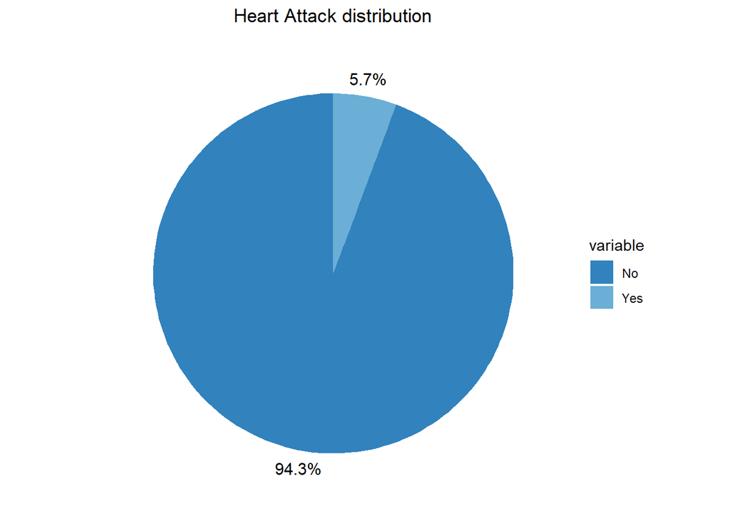

```r
plot_pie_freq(df$HadHeartAttack, "Heart Attack distribution")
```

We can observe that it’s quite unbalanced, only `5.7%` of observations present having a heart attack. To solve this class unbalance, we’ll employ data [undersampling](https://en.wikipedia.org/wiki/Undersampling) to reduce the amount of observations to the class exhibiting the least frequency; In this case, patients having a heart attack

## Raw Data Analysis

### Non-numeric values

One of the best practices is to perform data analysis on the dataset to understand what we have and how it is structured. This will help us determine if there is a need to correct or eliminate values to ensure that our study and tests are accurate, without being affected by data inconsistencies. So, let’s start by visualizing if we have any missing values and examining their distribution.

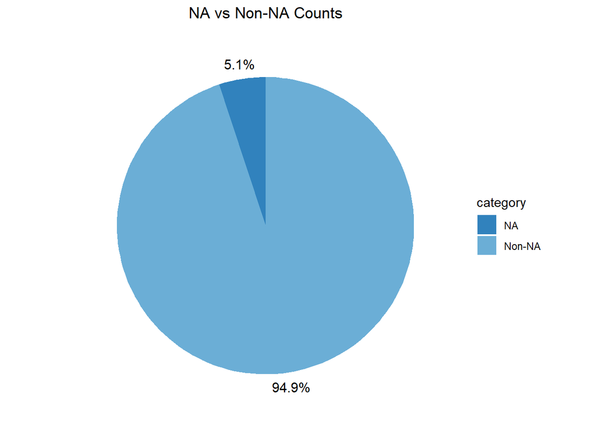

```r
pie_data <- data.frame(
  category = c("NA", "Non-NA"),
  count = c(sum(is.na(df)), sum(!is.na(df)))
) |>
  mutate(
    percentage = round(count / sum(count) * 100, 2)
  )

color_palette <- pals::stepped3(n = length(unique(pie_data)))
ggplot(pie_data, aes(x = "", y = count, fill = category)) +
  geom_bar(stat = "identity", width = 1) +
  geom_text(
    aes(x = 1.6, label = sprintf("%.1f%%", count / sum(count) * 100)),
    position = position_stack(vjust = 0.5),
    size = 4
  ) +
  coord_polar(theta = "y") +
  labs(title = "NA vs Non-NA Counts") +
  scale_fill_manual(values = color_palette) +
  theme_void() +
  theme(
    axis.title.x = element_blank(),
    axis.title.y = element_blank(),
    plot.title = element_text(hjust = 0.5)
  )
```

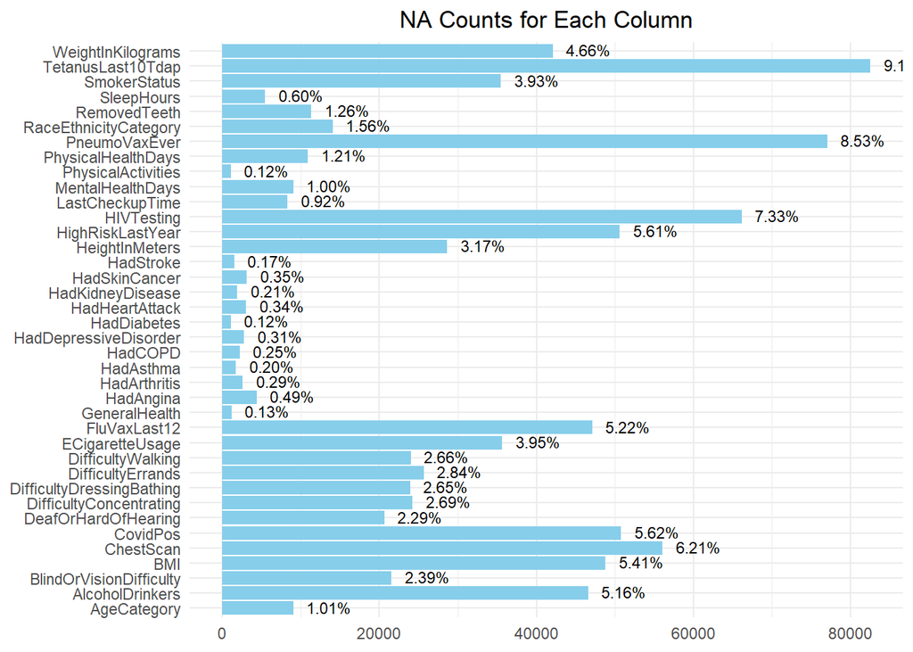

```r
na_df <- tibble(
  column = names(df),
  na_count = colSums(is.na(df))
) |>
  filter(na_count > 0) |>
  arrange(desc(na_count))

ggplot(
  na_df,
  aes(
    x = column,
    y = na_count,
    label = scales::percent(na_count / sum(na_count), accuracy = 0.01)
  )
) +
  geom_bar(
    stat = "identity",
    fill = "skyblue",
    position = "dodge"
  ) +
  geom_text(
    aes(label = scales::percent(na_count / sum(na_count), accuracy = 0.01)),
    position = position_dodge(width = 1),
    vjust = 0.4,
    hjust = -0.3,
    size = 3
  ) +
  labs(title = "NA Counts for Each Column") +
  theme_minimal() +
  theme(
    axis.text.y = element_text(hjust = 1),
    axis.title.x = element_blank(),
    axis.title.y = element_blank(),
    plot.title = element_text(hjust = 0.5)
  ) +
  coord_flip()
```

In this table we can see the percentages of NA’s for each column of the dataset. The column with the highest amount of NA’s is `TetanusLast10TDap (9.1%)` and the one with the least of amount are `HadDiabetes` and `PhysicalActivities (0.12%)`. Because of the different types of variables, we are going to take care of the NA’s in different ways.

As the amount of NA values is considerable, we’ll study the distribution of them per rows to further identify the severity of these missing values:

```r
na_group_threshold <- 5

na_count <- df |>
  is.na() |>
  rowSums() |>
  table() |>
  as.data.frame() |>
  mutate(across(is.factor, as.numeric)) |>
  rename(num_na = Var1) |>
  mutate(num_na = num_na - 1)
na_count_unbounded <- na_count

na_count <- na_count |>
  filter(num_na <= na_group_threshold) |>
  mutate(num_na = as.character(num_na)) |>
  bind_rows(
    data.frame(
      num_na = paste0(na_group_threshold, "+"),
      Freq = sum(na_count$Freq[as.numeric(na_count$num_na) > na_group_threshold])
    )
  )
```

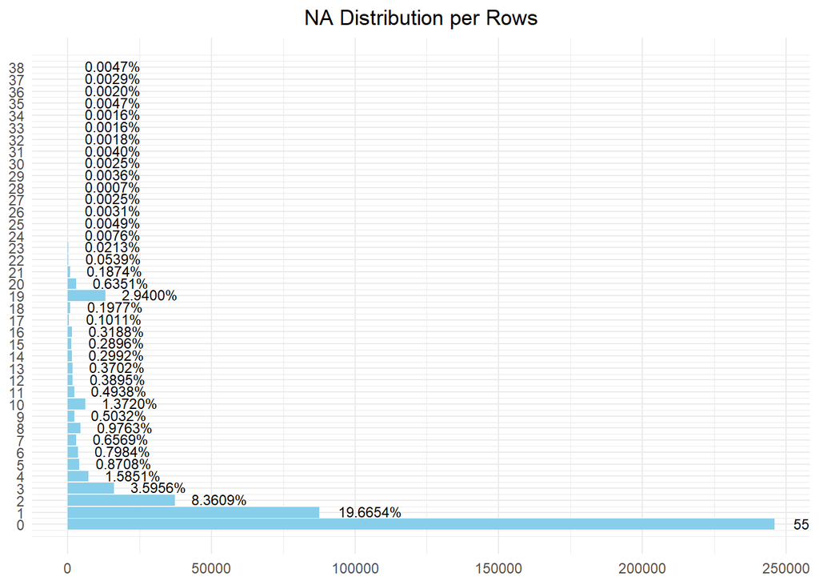

```r
ggplot(
  na_count_unbounded,
  aes(
    x = num_na,
    y = Freq,
    label = scales::percent(Freq / sum(Freq), accuracy = 0.0001)
  )
) +
  geom_bar(
    stat = "identity",
    fill = "skyblue",
    position = "dodge"
  ) +
  geom_text(
    aes(label = scales::percent(Freq / sum(Freq), accuracy = 0.0001)),
    position = position_dodge(width = 1), # Adjust width as needed
    vjust = 0.4, # Adjust vertical position of labels
    hjust = -0.3,
    size = 3 # Adjust text size
  ) +
  labs(title = "NA Distribution per Rows") +
  theme_minimal() +
  theme(
    axis.text.y = element_text(hjust = 1),
    axis.title.x = element_blank(),
    axis.title.y = element_blank(),
    plot.title = element_text(hjust = 0.5)
  ) +
  coord_flip() +
  scale_x_continuous(
    breaks = na_count_unbounded$num_na,
    labels = na_count_unbounded$num_na
  )
```

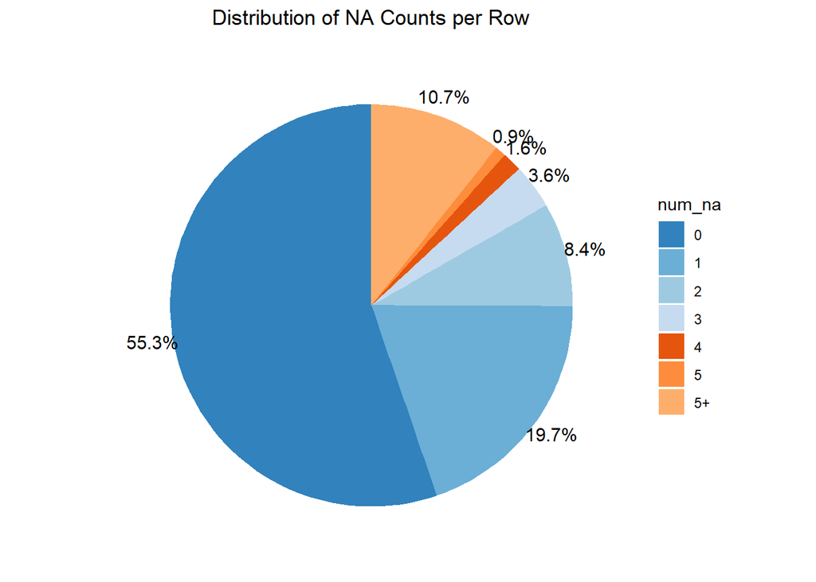

```r
color_palette <- pals::stepped3(n = length(unique(na_count$num_na)))
ggplot(na_count, aes(x = "", y = Freq, fill = num_na, label = sprintf("%.1f%%", Freq / sum(Freq) * 100))) +
  geom_bar(stat = "identity", width = 1) +
  geom_text(
    aes(x = 1.6, label = sprintf("%.1f%%", Freq / sum(Freq) * 100)),
    position = position_stack(vjust = 0.5),
    size = 4
  ) + # Add labels
  coord_polar(theta = "y") +
  labs(title = "Distribution of NA Counts per Row") +
  scale_fill_manual(values = color_palette) + # Use the chosen color palette
  theme_void() +
  theme(
    axis.text.y = element_blank(),
    axis.title.x = element_blank(),
    axis.title.y = element_blank(),
    plot.title = element_text(hjust = 0.5)
  )
```

As shown by the pie chart above, there are `10.7%` of observations that contain more than 5 NA. These observations could be deemed as impractical for our data analysis due to the extensive data corruption. As such, these could be systematically removed in subsequent stages of the analysis. The decision to remove them instead of manage them is related on the acknowledgment that these observations could mislead the data analysis.

## Data cleanup

### Removal of “corrupted” data

Since we have several rows with many missing values deemed as *corrupt observations*, we’ll proceed to remove them. If the number of missing values in a row exceeds **5**, the corresponding row will be deleted.

```r
df <- df[rowSums(is.na(df)) <= 5, ]
```

### Variable recodifications

We continue the data processing by categorizing the different variables, as it will assist us in interpreting the data. For example, grouping ages will make it easier to identify patterns. This will help in the future to reduce the complexity of linear models and trees.

#### Age

We’ll group the ages in the following categories, based on our own criteria:

- Very young: [0,25)
- Young: [25,35)
- Mature: [35,50)
- Senior: [50,65)
- Old: [65,80)
- Very old: [80,inf)

```r
df <- df |>
  mutate(
    AgeCategory = case_when(
      AgeCategory %in% c("Age 18 to 24") ~ "very young",
      AgeCategory %in% c("Age 25 to 29", "Age 30 to 34") ~ "young",
      AgeCategory %in% c("Age 35 to 39", "Age 40 to 44", "Age 45 to 49") ~ "mature",
      AgeCategory %in% c("Age 50 to 54", "Age 55 to 59", "Age 60 to 64") ~ "senior",
      AgeCategory %in% c("Age 65 to 69", "Age 70 to 74", "Age 75 to 79") ~ "old",
      AgeCategory %in% c("Age 80 or older") ~ "very old",
      is.na(AgeCategory) ~ "not known",
      TRUE ~ AgeCategory
    )
  ) |>
  mutate(AgeCategory = factor(
    AgeCategory,
    levels = c("very young", "young", "mature", "senior", "old", "very old", "not known")
  ))

df |> count(AgeCategory)
```

```
##   AgeCategory      n
## 1  very young  24159
## 2       young  42629
## 3      mature  77305
## 4      senior 103038
## 5         old 112237
## 6    very old  32512
## 7   not known   5833
```

Finally, we can see the distribution of age between the data of the dataset:

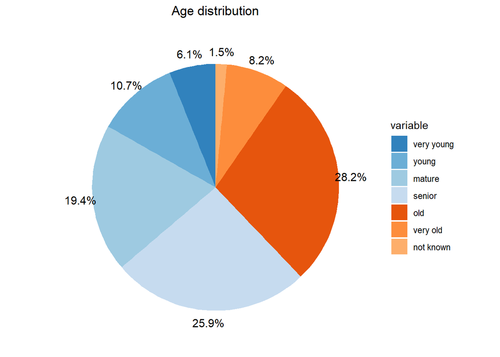

```r
plot_pie_freq(df$AgeCategory, "Age distribution")
```

We can see that there is approximately a `63%` of people older than 50.

#### Tetanus

```r
df <- df |>
  mutate(
    TetanusVaccinated = ifelse(
      str_detect(TetanusLast10Tdap, "^Yes"),
      "Yes",
      "No"
    ),
    TetanusVaccinated = as.factor(TetanusVaccinated)
  )
df <- df |> select(-TetanusLast10Tdap)
```

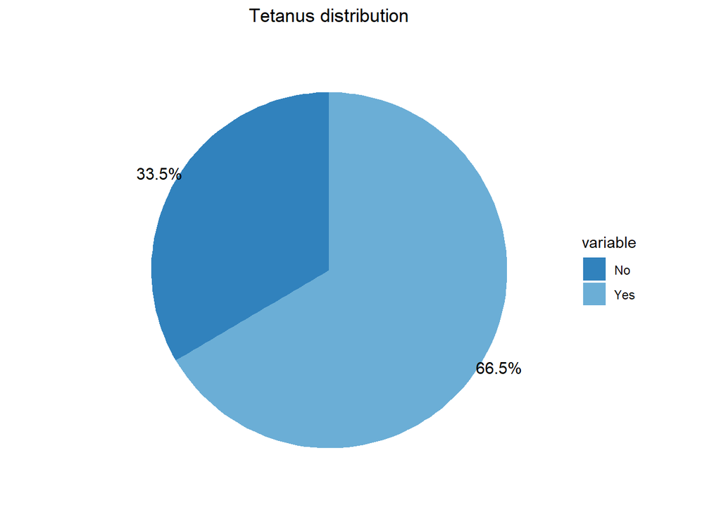

```r
plot_pie_freq(df$TetanusVaccinated, "Tetanus distribution")
```

Of the tetanus distribution we can see that it’s an unbalanced class, having a `66.5%` of Yes and a `33.5%` of No.

#### Smoker

This class is an interesting one, we have decided to merge `ECigaretteUsage` and `SmokerStatus` as they convey the same semantic information of whether a person has smoked in his life. Firstly, we’ll further discretize the values of each class:

```r
df <- df |>
  mutate(
    ECigaretteUsage = case_when(
      ECigaretteUsage == "Not at all (right now)" ~ "No",
      ECigaretteUsage == "Never used e-cigarettes in my entire life" ~ "No",
      ECigaretteUsage == "Use them every day" ~ "Yes",
      ECigaretteUsage == "Use them some days" ~ "Yes",
      TRUE ~ NA
    ),
    ECigaretteUsage = as.factor(ECigaretteUsage)
  )

df <- df |>
  mutate(
    SmokerStatus = case_when(
      SmokerStatus == "Never smoked" ~ "No",
      SmokerStatus == "Former smoker" ~ "Yes",
      SmokerStatus == "Current smoker - now smokes some days" ~ "Yes",
      SmokerStatus == "Current smoker - now smokes every day" ~ "Yes",
      TRUE ~ NA
    ),
    SmokerStatus = as.factor(SmokerStatus)
  )
```

The distribution of the `SmokerStatus` is the following:

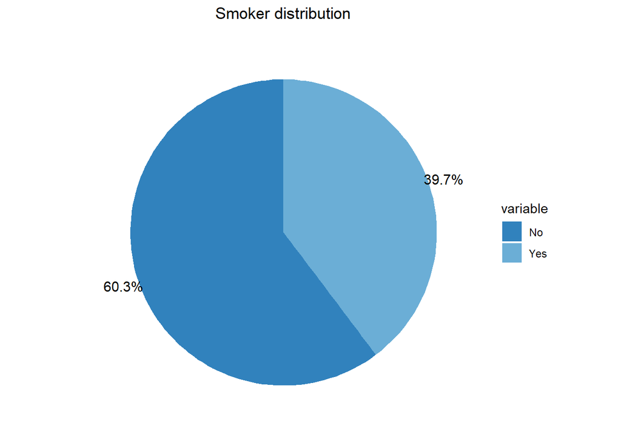

```r
plot_pie_freq(df$SmokerStatus, "Smoker distribution")
```

The distribution of the `EcigaretteUsage` is the following:

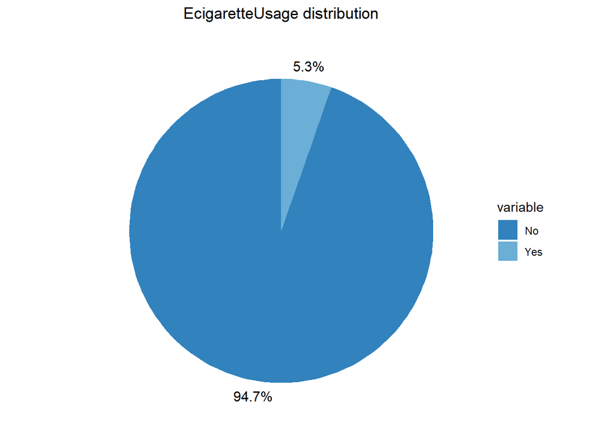

```r
plot_pie_freq(df$ECigaretteUsage, "EcigaretteUsage distribution")
```

In this case we will need to do something with this class as it presents a high imbalance. As stated above, we plan on merging these two variables; such implementation can be found on further chapters when tackling variable fusion.

#### Race

In the case of `RaceEthnicityCategory`, we decided to include the NA’s, about 10k observations, in the `Multiracial` category. This decision aims to help balance the classes, as this category currently has 8k entries.

```r
df <- df |>
  mutate(
    RaceEthnicityCategory = case_when(
      RaceEthnicityCategory == "Black only, Non-Hispanic" ~ "Black",
      RaceEthnicityCategory == "Multiracial, Non-Hispanic" ~ "Multiracial",
      RaceEthnicityCategory == "White only, Non-Hispanic" ~ "White",
      RaceEthnicityCategory == "Other race only, Non-Hispanic" ~ "Other",
      is.na(RaceEthnicityCategory) ~ "Multiracial",
      TRUE ~ RaceEthnicityCategory
    ),
    RaceEthnicityCategory = as.factor(RaceEthnicityCategory)
  )
```

The distribution by race is the following:

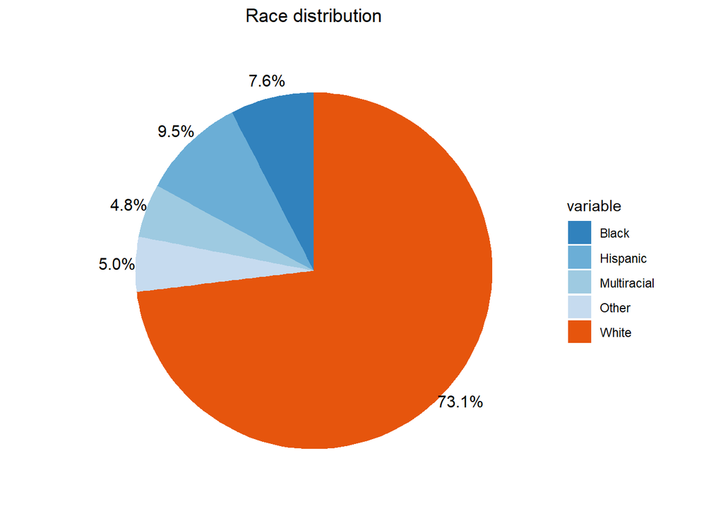

```r
plot_pie_freq(df$RaceEthnicityCategory, "Race distribution")
```

As we can see there is the vast majority of people is `White` making this variable to maybe not be as good as others because of the imbalance.

#### Last check-up time

For `LastCheckupTime` we have decided to make our own factorization of the data, we have concluded that there is not a good or logical way to predict the NA’s because it doesn’t make sense to know if a person has gone to a check up using other variables. This took us to make the decision to make all the NA’s part of the category of 5 or more years to try to balance the classes.

```r
df <- df |>
  mutate(
    YearsSinceCheckup = case_when(
      LastCheckupTime == "Within past year (anytime less than 12 months ago)" ~ 1,
      LastCheckupTime == "Within past 2 years (1 year but less than 2 years ago)" ~ 2,
      LastCheckupTime == "Within past 5 years (2 years but less than 5 years ago)" ~ 5,
      LastCheckupTime == "5 or more years ago" ~ 6,
      is.na(LastCheckupTime) ~ 6,
      TRUE ~ 6
    )
  )

df <- df |> select(-LastCheckupTime)

df |> count(YearsSinceCheckup)
```

```
##   YearsSinceCheckup      n
## 1                 1 314221
## 2                 2  37451
## 3                 5  22374
## 4                 6  23667
```

Here we can find the distribution of the `YearsSinceCheckup`:

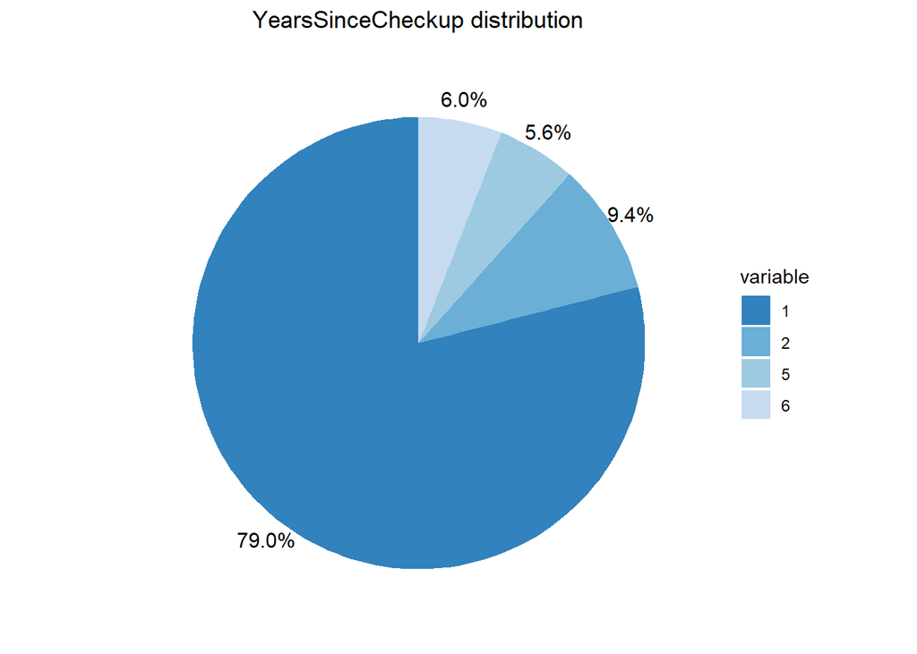

```r
plot_pie_freq(df$YearsSinceCheckup, "YearsSinceCheckup distribution")
```

Even though we have tried to balance the classes we can see that there is a high unbalance of them.

#### Removed Teeth

For `RemovedTeeth` we have supossed that if we don’t know if any teeth has been removed `None` of them have been removed.

```r
df <- df |>
  mutate(
    RemovedTeeth = case_when(
      is.na(RemovedTeeth) ~ "None of them",
      TRUE ~ RemovedTeeth
    ),
    RemovedTeeth = as.factor(RemovedTeeth)
  )

table(df$RemovedTeeth)
```

```
##
##                 1 to 5 6 or more, but not all                    All
##                 116152                  41097                  22638
##           None of them
##                 217826
```

The distribution of `RemovedTeeth` is:

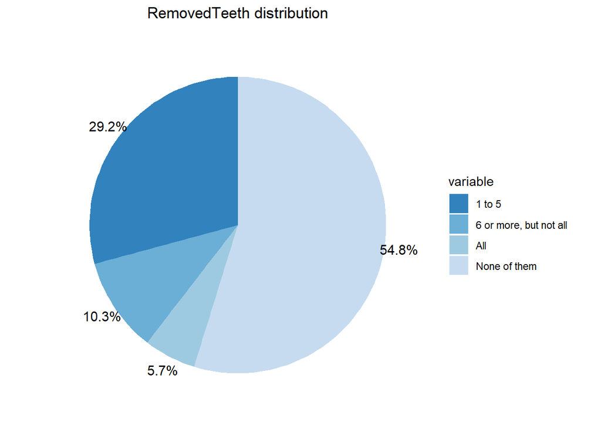

```r
plot_pie_freq(df$RemovedTeeth, "RemovedTeeth distribution")
```

As we can see if we take every class individually we can see the imbalance but if we look closer we can see that there is a `54.8%` of people that has not lost any teeth and a `45.2%` that has lost at least 1.

#### Sleep

Before seeing the distribution let’s categorize this variable, taking in consideration the medical consensus found in an [official website ot the United States government](https://pubmed.ncbi.nlm.nih.gov/29073398/). We have decided to make all the NA’s as “Optimal” because is the mean of hours that people normally sleeps.

```r
df <- df %>%
  mutate(
    Sleep = case_when(
      SleepHours %in% 1:5 | SleepHours %in% 11:24 ~ "Not Appropriate",
      SleepHours %in% c(6, 10) ~ "Appropriate",
      SleepHours %in% 7:9 ~ "Optimal",
      is.na(SleepHours) ~ "Optimal",
    ),
    Sleep = as.factor(Sleep)
  )

df <- df |> select(-SleepHours)
```

Here we can see the distribution:

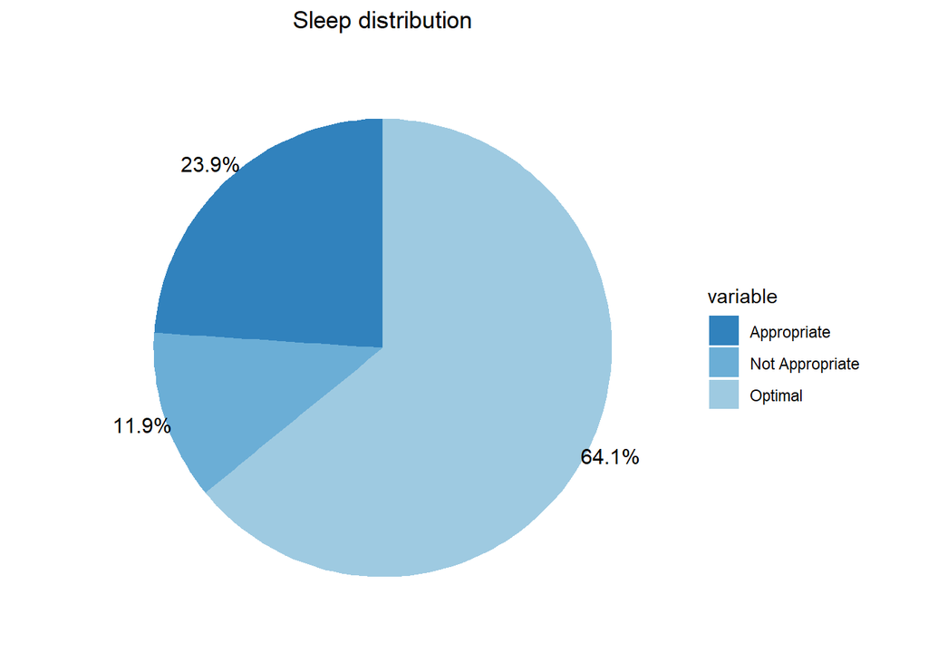

```r
plot_pie_freq(df$Sleep, "Sleep distribution")
```

As we can see there is a `64.1%` of people that sleeps the reccomended amount of hours, on the other hand we have a `23.9%` of people that sleeps 6 or 10 hours, and a `11.9%` of people that sleeps less than 6 hours or more than 10.

#### Mental and Physical

Mental and Physical health days exhibit values from 0-30. Preliminary observation suggests the existence of three distinct clusters within these variables. To objectively validate this intuition, we’ll apply hierarchical clusterization. The next step involves the assignment of semantic labels:

- High
- Medium
- Low

With the intent of creating a new varialbe that will replace the original one, representing the index of health of the given replaced one.

As the clustering process cannot be done to the whole dataset, yielding an *infinite depth* error, a sample of the data will be used instead. Consequently, as we want the whole data domain to be taken into account we won’t be creating a fully random subset. We’ll first insert one value for each class (0-30) and fill the remaining slots with true random samples.

```r
set.seed(29)

mhd_df <- data.frame(df$MentalHealthDays) |>
  na.omit() %>%
  slice_sample(n = 1170) # Remove 30 items that we will insert manually

mhd_df <- Reduce(
  function(x, y) merge(x, y, all = TRUE),
  list(mhd_df, tibble(df.MentalHealthDays = 0:30))
)

table(mhd_df)
```

```
## df.MentalHealthDays
##   0   1   2   3   4   5   6   7   8   9  10  11  12  13  14  15  16  17  18  19
## 712  36  49  36  25  58   7  21   5   2  36   1   4   1  13  50   1   1   1   1
##  20  21  22  23  24  25  26  27  28  29  30
##  26   1   1   1   1   5   1   2   1   1  77
```

With this we assure that at least we have one value for each day (as we’ll be ignoring the NA values for obvious reasons)

```r
mhd_labels <- make_hclust(
  mhd_df |> scale(),
  "MentalHealthDays Clustering Dendrogram"
) %>%
  tibble(Cluster_labels = .) %>%
  mutate(Cluster_labels = case_when(
    Cluster_labels == 1 ~ "High",
    Cluster_labels == 2 ~ "Medium",
    Cluster_labels == 3 ~ "Low"
  ))
mhd_summary <- cbind(mhd_df, mhd_labels) |>
  group_by(Cluster_labels) |>
  summarise(
    MinValue = min(df.MentalHealthDays),
    MaxValue = max(df.MentalHealthDays)
  )
```

We’ll create a new variable that discretizes the current numerical variable and remove the original numerical data

```r
df <- df |>
  mutate(
    MentalHealthIndex = case_when(
      MentalHealthDays %in% mhd_summary$MinValue[1]:mhd_summary$MaxValue[1] ~ mhd_summary$Cluster_labels[1],
      MentalHealthDays %in% mhd_summary$MinValue[2]:mhd_summary$MaxValue[2] ~ mhd_summary$Cluster_labels[2],
      MentalHealthDays %in% mhd_summary$MinValue[3]:mhd_summary$MaxValue[3] ~ mhd_summary$Cluster_labels[3],
    ),
    MentalHealthIndex = as.factor(MentalHealthIndex)
  )

df <- df |> select(-MentalHealthDays)
```

We will apply the same as we did for the mental health days, but this time we will use the `PhysicalHealthDays` variable.

```r
set.seed(29)

# Create a subset of data, ignoring NA and taking a sample of 1200 observations
phd_df <- data.frame(df$PhysicalHealthDays) |>
  na.omit() %>%
  slice_sample(n = 1170) # Remove 30 items that we will insert manually

phd_df <- Reduce(
  function(x, y) merge(x, y, all = TRUE),
  list(phd_df, tibble(df.PhysicalHealthDays = 0:30))
)

# Clusterize the data and assign semantic labels for each one of them
phd_labels <- make_hclust(
  phd_df |> scale(),
  "PhysicalHealthDays Clustering Dendrogram"
) %>%
  tibble(Cluster_labels = .) %>%
  mutate(Cluster_labels = case_when(
    Cluster_labels == 1 ~ "High",
    Cluster_labels == 2 ~ "Medium",
    Cluster_labels == 3 ~ "Low"
  ))

# Create a range summary for each of the semantic labels
phd_summary <- cbind(phd_df, phd_labels) |>
  group_by(Cluster_labels) |>
  summarise(
    MinValue = min(df.PhysicalHealthDays),
    MaxValue = max(df.PhysicalHealthDays)
  )

# Create a new variable that discretizes the current numerical variable
df <- df |>
  mutate(
    PhysicalHealthIndex = case_when(
      PhysicalHealthDays %in% phd_summary$MinValue[1]:phd_summary$MaxValue[1] ~ phd_summary$Cluster_labels[1],
      PhysicalHealthDays %in% phd_summary$MinValue[2]:phd_summary$MaxValue[2] ~ phd_summary$Cluster_labels[2],
      PhysicalHealthDays %in% phd_summary$MinValue[3]:phd_summary$MaxValue[3] ~ phd_summary$Cluster_labels[3],
    ),
    PhysicalHealthIndex = as.factor(PhysicalHealthIndex)
  )

# Remove the original numerical data
df <- df |> select(-PhysicalHealthDays)
```

### Predictive models

To conclude with the missing values, we will attempt to predict the features with NA’s using observations without any missing values, which constitute 61% of the data. The variables we are trying to predict are binary, meaning they have values of ‘Yes’ or ‘No.’ We will use a decision tree, we will substitute all the values predicted but, we have to take into consideration that there are some that doesn’t exceed our threshold, i.e., accuracy > 0.8.

```r
non_na <- df[rowSums(is.na(df)) == 0, ]
na_rows <- df[rowSums(is.na(df)) > 0, ]
na_rows_mutable <- df[rowSums(is.na(df)) > 0, ]

data_split <- initial_split(non_na, prop = 0.8)

bool_cols <- df %>%
  select(where(~ all(. %in% c("Yes", "No", NA)))) |>
  select(-HadHeartAttack) |>
  colnames()

model <- decision_tree(
  engine = "rpart",
  mode = "classification"
)

for (name in bool_cols) {
  cat("[DOING  ]", name, "\n")
  model_output <- model_accuracy(
    model,
    training(data_split),
    testing(data_split),
    name
  )

  if (model_output$metrics$accuracy < 0.8) {
    cat("[WARNING]", name, "had a subpar accuracy of", model_output$metrics$accuracy, "\n")
  }

  cat("[REPLACE]", name, "is a good candidate, having an accuracy of", model_output$metrics$accuracy, "\n")

  pred <- model_output$model |>
    predict(na_rows) |>
    pull(.pred_class)

  # Replace only the missing values in na_rows for the given column
  for (value in seq_along(na_rows_mutable[[name]])) {
    if (is.na(na_rows_mutable[[name]][value])) {
      na_rows_mutable[[name]][value] <- pred[value]
    }
  }
}
```

```
## [DOING  ] PhysicalActivities
## [WARNING] PhysicalActivities had a subpar accuracy of 0.7893382
## [REPLACE] PhysicalActivities is a good candidate, having an accuracy of 0.7893382
## [DOING  ] HadAngina
## [REPLACE] HadAngina is a good candidate, having an accuracy of 0.9435438
## [DOING  ] HadStroke
## [REPLACE] HadStroke is a good candidate, having an accuracy of 0.9590883
## [DOING  ] HadAsthma
## [REPLACE] HadAsthma is a good candidate, having an accuracy of 0.8531184
## [DOING  ] HadSkinCancer
## [REPLACE] HadSkinCancer is a good candidate, having an accuracy of 0.9153538
## [DOING  ] HadCOPD
## [REPLACE] HadCOPD is a good candidate, having an accuracy of 0.9258058
## [DOING  ] HadDepressiveDisorder
## [REPLACE] HadDepressiveDisorder is a good candidate, having an accuracy of 0.8284188
## [DOING  ] HadKidneyDisease
## [REPLACE] HadKidneyDisease is a good candidate, having an accuracy of 0.9553691
## [DOING  ] HadArthritis
## [WARNING] HadArthritis had a subpar accuracy of 0.7260919
## [REPLACE] HadArthritis is a good candidate, having an accuracy of 0.7260919
## [DOING  ] DeafOrHardOfHearing
## [REPLACE] DeafOrHardOfHearing is a good candidate, having an accuracy of 0.9119016
## [DOING  ] BlindOrVisionDifficulty
## [REPLACE] BlindOrVisionDifficulty is a good candidate, having an accuracy of 0.9484074
## [DOING  ] DifficultyConcentrating
## [REPLACE] DifficultyConcentrating is a good candidate, having an accuracy of 0.9040816
## [DOING  ] DifficultyWalking
## [REPLACE] DifficultyWalking is a good candidate, having an accuracy of 0.888499
## [DOING  ] DifficultyDressingBathing
## [REPLACE] DifficultyDressingBathing is a good candidate, having an accuracy of 0.967614
## [DOING  ] DifficultyErrands
## [REPLACE] DifficultyErrands is a good candidate, having an accuracy of 0.9392523
## [DOING  ] SmokerStatus
## [WARNING] SmokerStatus had a subpar accuracy of 0.6738127
## [REPLACE] SmokerStatus is a good candidate, having an accuracy of 0.6738127
## [DOING  ] ECigaretteUsage
## [REPLACE] ECigaretteUsage is a good candidate, having an accuracy of 0.9489605
## [DOING  ] ChestScan
## [WARNING] ChestScan had a subpar accuracy of 0.6407782
## [REPLACE] ChestScan is a good candidate, having an accuracy of 0.6407782
## [DOING  ] AlcoholDrinkers
## [WARNING] AlcoholDrinkers had a subpar accuracy of 0.6195117
## [REPLACE] AlcoholDrinkers is a good candidate, having an accuracy of 0.6195117
## [DOING  ] HIVTesting
## [WARNING] HIVTesting had a subpar accuracy of 0.6886706
## [REPLACE] HIVTesting is a good candidate, having an accuracy of 0.6886706
## [DOING  ] FluVaxLast12
## [WARNING] FluVaxLast12 had a subpar accuracy of 0.6567614
## [REPLACE] FluVaxLast12 is a good candidate, having an accuracy of 0.6567614
## [DOING  ] PneumoVaxEver
## [WARNING] PneumoVaxEver had a subpar accuracy of 0.768148
## [REPLACE] PneumoVaxEver is a good candidate, having an accuracy of 0.768148
## [DOING  ] HighRiskLastYear
## [REPLACE] HighRiskLastYear is a good candidate, having an accuracy of 0.9570475
## [DOING  ] TetanusVaccinated
## [WARNING] TetanusVaccinated had a subpar accuracy of 0.6627122
## [REPLACE] TetanusVaccinated is a good candidate, having an accuracy of 0.6627122
```

We merge the rows with non-NA and those rows that the NA value has been predicted.

```r
df <- Reduce(
  function(x, y) merge(x, y, all = TRUE),
  list(non_na, na_rows_mutable)
)
```

### Recodification

We’ll map the “Yes/No” values to 1/0 respectively to make it easier to work with them

```r
bool_cols <- df |>
  select(where(~ any(. %in% c("Yes", "No")))) |>
  colnames()

for (col in bool_cols) {
  df[[col]] <- ifelse(df[[col]] == "No", 0, 1)
}
```

### Fusion of classes

#### Smoking

```r
df <- df |>
  mutate(
    HasSmoked = case_when(
      SmokerStatus == 0 | ECigaretteUsage == 0 ~ 0,
      is.na(SmokerStatus) & is.na(ECigaretteUsage) ~ sample(c(1, 0), 1, replace = TRUE),
      is.na(SmokerStatus) ~ ECigaretteUsage,
      is.na(ECigaretteUsage) ~ SmokerStatus,
      TRUE ~ 1
    )
  )

df <- df |> select(-SmokerStatus, -ECigaretteUsage)
```

Here we have the distribution:

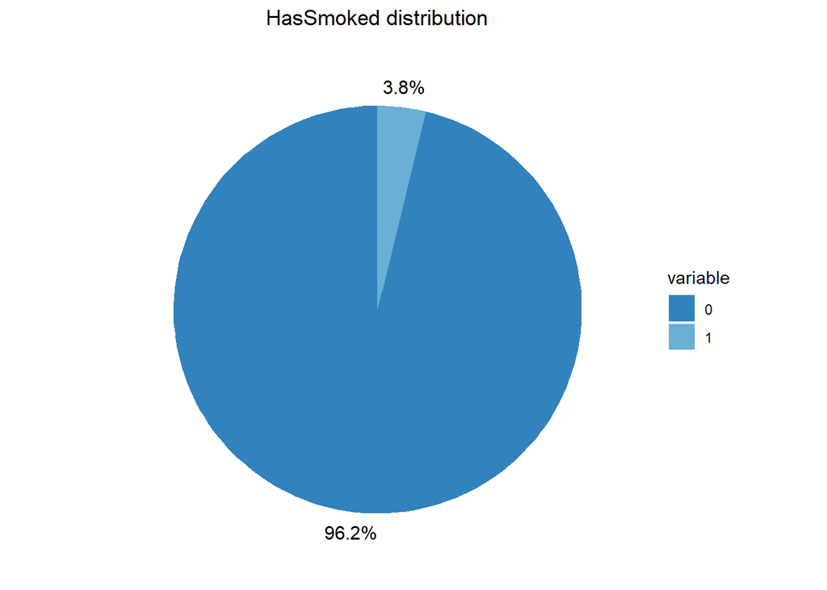

```r
plot_pie_freq(df$HasSmoked, "HasSmoked distribution")
```

#### Difficulties

Now we’ll try to explore the correlation between the difficulties to see if we can merge them into a single variable

```r
corr_df <- na.omit(df)
ggcorr(
  corr_df %>% select(contains("Difficulty")),
  label = TRUE,
  label_round = 2,
  hjust = 0.75,
  angle = -45
)
```

[figure not shown]

As we can see, the difficulties are somewhat correlated, so we’ll create a new variable `LifeDifficulties` by adding them to account for multiple difficulties at the same time.

```r
df <- df %>%
  mutate(
    LifeDifficulties = rowSums(select(., contains("Difficulty"))),
    across(contains("Difficulty"), ~NULL)
  )
```

### WeightInKilograms and HeightInMeters treatment

Now we can use all the data in the dataset to predict the height and the weight.

```r
weight_model <- rpart(WeightInKilograms ~ ., data = df, method = "anova")
df$WeightInKilograms[is.na(df$WeightInKilograms)] <- predict(weight_model, newdata = df[is.na(df$WeightInKilograms), ])
model_statistics(num_samples = 10000, target_variable = "WeightInKilograms", dataframe = df)
```

```
## # A tibble: 1 × 2
##   accuracy std_deviation
##      <dbl>         <dbl>
## 1    0.839          8.62
```

We can see a `84%` of accuracy when predicting Weight.

```r
height_model <- rpart(HeightInMeters ~ ., data = df, method = "anova")
df$HeightInMeters[is.na(df$HeightInMeters)] <- predict(height_model, newdata = df[is.na(df$HeightInMeters), ])
model_statistics(num_samples = 10000, target_variable = "HeightInMeters", dataframe = df)
```

```
## # A tibble: 1 × 2
##   accuracy std_deviation
##      <dbl>         <dbl>
## 1    0.677        0.0608
```

After predicting the values of `WeightInKilograms` and `HeightInMeters` we can calculate the BMI of those values that are NA using it’s formula:

$$BMI =
\frac{Weight}{Height^2}$$

```r
df$BMI <- df$WeightInKilograms / (df$HeightInMeters^2)

df <- df |> select(-WeightInKilograms, -HeightInMeters)
```

```r
BMI_subset <- subset(df, select = c("State", "BMI", "HadHeartAttack"))
```

After the calculation we can remove `WeightInKilograms` and `HeightInMeters` because they are redundant once we have BMI.

#### BMI

Exploring the BMI distribution

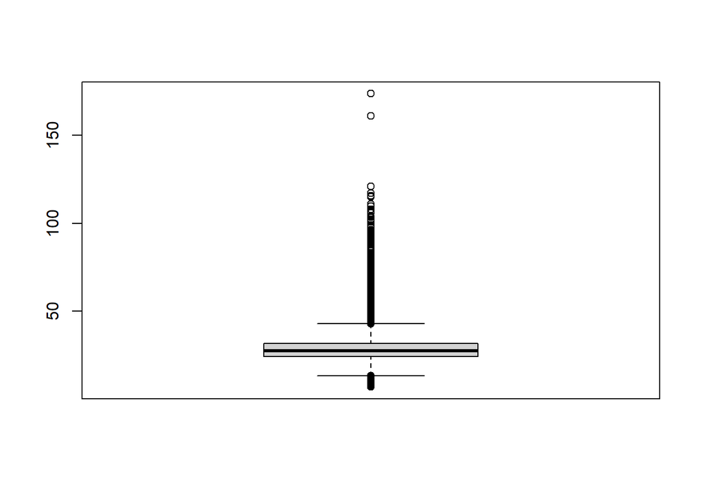

```r
boxplot(df$BMI)
```

Seeing the distribution of the BMI, we can see that there are some outliers, to deal with them we’ll group them into categories based on the CDC’s BMI classification. See [this](https://www.cdc.gov/obesity/basics/adult-defining.html#:~:text=If%20your%20BMI%20is%20less,falls%20within%20the%20obesity%20range) link: The categories are:

- Underweight: BMI is less than 18.5
- Healthy weight: BMI is 18.5 to 24.9
- Overweight: BMI is 25 to 29.9
- Obese: BMI of 30 or greater
  - Obese Class 1: BMI of 30 to 34.9
  - Obese Class 2: BMI of 35 to 39.9
  - Obese Class 3: BMI of 40 or greater

```r
bmi_categories <- c("Underweight", "Healthy Weight", "Overweight", "Obese C1", "Obese C2", "Obese C3")
bmi_ranges <- c(0, 18.5, 24.9, 29.9, 34.9, 39.9, Inf)

df$BMI <- cut(
  df$BMI,
  breaks = bmi_ranges,
  labels = bmi_categories,
  include.lowest = TRUE
)
```

Once we have the categories, we can plot the distribution of the BMI

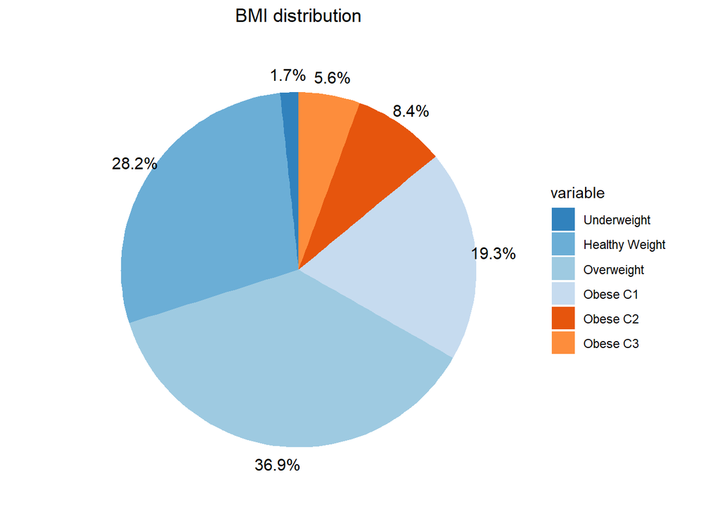

```r
plot_pie_freq(df$BMI, "BMI distribution")
```

### Duplicated observations

Once all the data is cleaned and all the variables are in the correct format, we can proceed to remove the duplicated observations. This is done to avoid having the same observation in both the training and testing sets, which would lead to overfitting.

We are removing all the duplicated observations, after applying the feature engineering and whatnot, to avoid having the same observation while we were cleaning the data.

```r
cat("Removing", sum(duplicated(df)), "duplicated observations")
```

```
## Removing 6465 duplicated observations
```

```r
df <- unique(df)
```

Finally, we can see the structure of the dataframe cleaned and ready to be used for analysis and the creation of models.

```r
str(df)
```

```
## 'data.frame':    391226 obs. of  33 variables:
##  $ State                : Factor w/ 54 levels "Alabama","Alaska",..: 1 1 1 1 1 1 1 1 1 1 ...
##  $ Gender               : Factor w/ 2 levels "Female","Male": 1 1 1 1 1 1 1 1 1 1 ...
##  $ GeneralHealth        : Factor w/ 5 levels "Excellent","Fair",..: 1 1 1 1 1 1 1 1 1 1 ...
##  $ PhysicalActivities   : num  0 0 0 0 0 0 0 0 0 0 ...
##  $ RemovedTeeth         : Factor w/ 4 levels "1 to 5","6 or more, but not all",..: 1 1 1 1 1 1 1 1 1 1 ...
##  $ HadHeartAttack       : num  0 0 0 0 0 0 0 0 0 0 ...
##  $ HadAngina            : num  0 0 0 0 0 0 0 0 0 1 ...
##  $ HadStroke            : num  0 0 0 0 0 0 0 0 0 0 ...
##  $ HadAsthma            : num  0 0 0 0 0 0 0 0 1 0 ...
##  $ HadSkinCancer        : num  0 0 0 0 0 0 0 0 0 0 ...
##  $ HadCOPD              : num  0 0 0 0 0 0 0 0 0 1 ...
##  $ HadDepressiveDisorder: num  0 0 0 0 0 0 1 1 0 1 ...
##  $ HadKidneyDisease     : num  0 0 0 0 0 0 0 0 0 1 ...
##  $ HadArthritis         : num  0 0 0 0 0 0 0 1 0 1 ...
```

[output cut: 19 more lines]

### NA check

```r
na_summary <- df %>%
  summarise_all(~ sum(is.na(.))) %>%
  select_if(~ . > 0) |>
  select(-HadHeartAttack)
```

Seeing this amount of NA’s we have concluded that the best way to take care of them is to add them to the class with least amount of observations for each variable with the objective of slightly balance the classes. As `HadHeartAttack` is our target, we won’t be replacing any NA values, instead, this subset will be used as input to our final predictive function.

```r
df <- df %>%
  mutate(across(colnames(na_summary), ~ ifelse(is.na(.), which.min(table(.)), .)))
```

```r
df %>%
  summarise_all(~ sum(is.na(.))) %>%
  select_if(~ . > 0)
```

```
##   HadHeartAttack
## 1           2116
```

### Export cleaned dataframe to csv

Save the cleaned dataframe to a csv file to be used in the `models.Rmd` file.

```r
write.csv(df, here("data", "clean.csv"))
```

## Data visualization

```r
ggcorr(
  df,
  label = TRUE,
  label_round = 2,
  hjust = 0.75,
  angle = -45
)
```

[figure not shown]

```r
state_abbreviations <- c("DC", "GU", "PR", "VI")

str(BMI_subset)
```

```
## 'data.frame':    397691 obs. of  3 variables:
##  $ State         : Factor w/ 54 levels "Alabama","Alaska",..: 1 1 1 1 1 1 1 1 1 1 ...
##  $ BMI           : num  25.7 26.6 31.7 19.7 27 ...
##  $ HadHeartAttack: num  0 0 0 0 0 0 0 0 0 0 ...
```

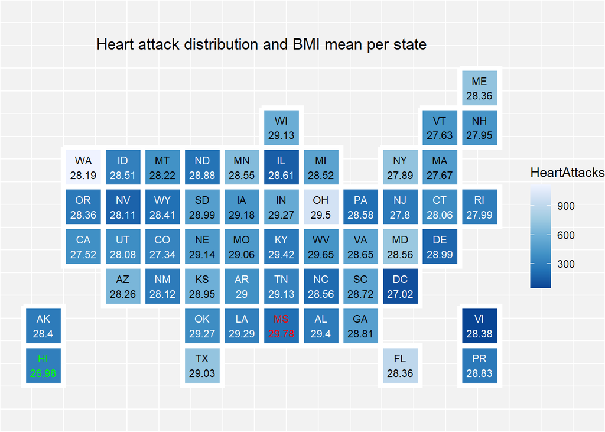

```r
BMI_state <- BMI_subset |>
  mutate(State = as.character(State)) |>
  group_by(State) |>
  summarize(
    mean_BMI = mean(BMI, na.rm = TRUE),
    HeartAttacks = sum(HadHeartAttack, na.rm = TRUE)
  ) |>
  arrange(State) |>
  mutate(StateAbb = state.abb[match(State, state.name)]) |>
  mutate(StateAbb = case_when(
    State == "District of Columbia" ~ "DC",
    State == "Guam" ~ "GU",
    State == "Puerto Rico" ~ "PR",
    State == "Virgin Islands" ~ "VI",
    TRUE ~ StateAbb
  ))

BMI_state$lab <- paste(BMI_state$StateAbb, round(BMI_state$mean_BMI, 2), sep = "\n")

BMI_state <- BMI_state |>
  filter(State != "Guam")

sb <- statebins(
  state_data = BMI_state,
  state_col = "State",
  value_col = "HeartAttacks"
) +
  labs(title = "Heart attack distribution and BMI mean per state") +
  theme_void() +
  theme(
    axis.title.x = element_blank(),
    axis.title.y = element_blank(),
    axis.text.x = element_blank(),
    axis.text.y = element_blank(),
    panel.grid.major = element_blank(),
    panel.grid.minor = element_blank(),
    panel.border = element_blank(),
    panel.background = element_blank(),
    axis.line = element_blank(),
    plot.title = element_text(hjust = 0.5),
    plot.background = element_blank(),
    strip.background = element_blank()
  )

max_bmi_state <- BMI_state[which.max(BMI_state$mean_BMI), "StateAbb"]
min_bmi_state <- BMI_state[which.min(BMI_state$mean_BMI), "StateAbb"]

# https://stackoverflow.com/questions/76574854/how-to-add-count-labels-to-statebin-map
sb <- ggplot_build(sb)
sb$data[[2]]$colour[sb$data[[2]]$label %in% max_bmi_state] <- "red"
sb$data[[2]]$colour[sb$data[[2]]$label %in% min_bmi_state] <- "green"
sb$data[[2]]$label <- BMI_state$lab[match(sb$data[[2]]$label, BMI_state$StateAbb)]
sb <- ggplot_gtable(sb)

plot(sb)
```

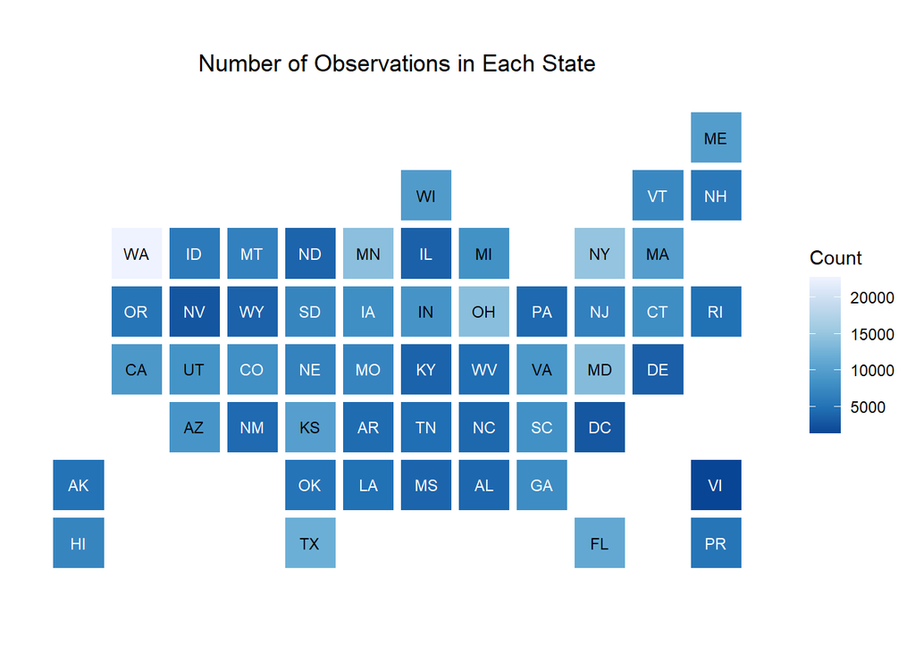

```r
state_counts <- table(df$State)

# Merge the counts with the original data
df_with_counts <- merge(
  df,
  data.frame(
    State = names(state_counts),
    Count = as.numeric(state_counts)
  ),
  by = "State",
  all.x = TRUE
)

# Plot the choropleth map using statebins_continuous
statebins(
  state_data = df_with_counts |> mutate(State = as.character(State)),
  state_col = "State",
  value_col = "Count"
) +
  labs(title = "Number of Observations in Each State") +
  theme_minimal() +
  theme(
    axis.title.x = element_blank(),
    axis.title.y = element_blank(),
    axis.text.x = element_blank(),
    axis.text.y = element_blank(),
    panel.grid.major = element_blank(),
    panel.grid.minor = element_blank(),
    panel.border = element_blank(),
    panel.background = element_blank(),
    axis.line = element_blank(),
    plot.title = element_text(hjust = 0.5)
  )
```

## Data prediction

```r
library(ggplot2)
library(tidymodels)
library(GGally)
library(here)
library(caret)
library(vip)
library(discrim)
library(gridExtra)
library(e1071)
library(rpart.plot)
library(rattle)
library(vip)
library(broom)

# Association rules
library(arules)
library(arulesViz)

library(conflicted)
conflicts_prefer(dplyr::setdiff)
conflicts_prefer(dplyr::filter)
conflicts_prefer(dplyr::select)
```

```r
df <- df |>
  mutate(across(where(is.factor), as.numeric))
```

### Data split

We’ll first separate the observations that contain a non numeric `HadHeartAttack`. The objective of this separation is to facilitate the predicion of `HadHeartAttack` values in future stages of the paper

```r
heart_attack_target <- df[is.na(df$HadHeartAttack), ] # 2116
df <- df[!is.na(df$HadHeartAttack), ]
df <- df |>
  mutate(HadHeartAttack = as.factor(HadHeartAttack))
```

Given that, we apply undersampling of the variable `HadHeartAttack`, as to offer a balanced dataset to our predictive models

```r
had_heart_attack <- df[df$HadHeartAttack == 1, ]

had_not_heart_attack <- df[df$HadHeartAttack == 0, ] |>
  slice_sample(n = nrow(had_heart_attack))

df <- Reduce(
  function(x, y) merge(x, y, all = TRUE),
  list(had_heart_attack, had_not_heart_attack)
)
```

Finally, a training and testing subset of the data is created with a ratio of 70% to 30%; 70% to train and 30% to test with `HadHeartAttack` as our target

```r
df_split <- initial_split(na.omit(df), prop = 0.70, strata = HadHeartAttack)
train <- training(df_split)
test <- testing(df_split)
```

To best study the capabilities of the cleaned dataset, and to not settle to one model, an arrangement of predictive models has been defined. All of them will be trained with the same data split, as to not create misleading accuracy discrepancies.

```r
models <- list(
  list(
    "name" = "logistical",
    "model" = logistic_reg(
      mode = "classification",
      engine = "glm",
    )
  ),
  list(
    "name" = "nearest_neighbor",
    "model" = nearest_neighbor(
      mode = "classification",
      engine = "kknn",
      neighbors = 10
    )
  ),
  list(
    "name" = "decision_tree",
    "model" = decision_tree(
      mode = "classification",
      engine = "rpart",
      tree_depth = 20
    )
  ),
  list(
    "name" = "rand_forest",
    "model" = rand_forest(
      mode = "classification"
    ) %>%
      set_engine("ranger", importance = "impurity")
  ),
  list(
    "name" = "bart",
    "model" = bart(
      mode = "classification",
      engine = "dbarts",
      trees = 100
    )
  ),
  list(
    "name" = "mars",
    "model" = mars(
      mode = "classification",
      engine = "earth",
    )
  ),
  list(
    "name" = "nn",
    "model" = mlp(
      mode = "classification",
      engine = "nnet",
      epochs = 100,
      hidden_units = 8,
      learn_rate = 0.01
    )
  ),
  list(
    "name" = "boost_tree",
    "model" = boost_tree(
      mode = "classification",
      engine = "xgboost",
      trees = 100,
      tree_depth = 10,
      min_n = 10,
      loss_reduction = 0.01,
      learn_rate = 0.01
    )
  ),
  list(
    "name" = "lda",
    "model" = discrim_linear(
      mode = "classification",
      engine = "MASS",
    )
  )
)

model_results <- map(models, ~ apply_model_training(
  .$name,
  .$model,
  train,
  test,
  "HadHeartAttack"
))
```

```
## [DOING] logistical
## [DOING] nearest_neighbor
```

```
## [DOING] decision_tree
## [DOING] rand_forest
## [DOING] bart
## [DOING] mars
```

```
## [DOING] nn
## [DOING] boost_tree
## [DOING] lda
```

### Naive Bayes

```r
modelo_nb <- naiveBayes(HadHeartAttack ~ ., data = train)
predicciones <- predict(modelo_nb, newdata = test)
matriz_confusion <- confusionMatrix(predicciones, test$HadHeartAttack)

df_bayes <- data.frame(
  Name = "naive bayes",
  Accuracy = matriz_confusion$overall[[1]],
  Kap = matriz_confusion$overall[[2]]
)
```

### Asociation rules

We considered the application of association rules given the categorical nature of most, if not all, variables present in our dataset. It’s important to note that, given the vast amount of variables within our dataset, we’re not expecting significant results

```r
transactions <- transactions(data.frame(lapply(df, as.factor)))
```

```r
supp_values <- c(0.3, 0.4)
conf_values <- c(0.6, 0.7, 0.8, 0.9)
minlen_values <- c(2, 3)

result_rules <- run_apriori_with_loop(
  transactions,
  supp_values,
  conf_values,
  minlen_values,
  verbose = TRUE
)
```

```
## [INFO] Doing... Support: 0.3 Confidence: 0.6 MinLength: 2
## [INFO] Doing... Support: 0.3 Confidence: 0.6 MinLength: 3
## [INFO] Doing... Support: 0.3 Confidence: 0.7 MinLength: 2
## [INFO] Doing... Support: 0.3 Confidence: 0.7 MinLength: 3
## [INFO] Doing... Support: 0.3 Confidence: 0.8 MinLength: 2
## [INFO] Doing... Support: 0.3 Confidence: 0.8 MinLength: 3
## [INFO] Doing... Support: 0.3 Confidence: 0.9 MinLength: 2
## [INFO] Doing... Support: 0.3 Confidence: 0.9 MinLength: 3
## [INFO] Doing... Support: 0.4 Confidence: 0.6 MinLength: 2
## [INFO] Doing... Support: 0.4 Confidence: 0.6 MinLength: 3
## [INFO] Doing... Support: 0.4 Confidence: 0.7 MinLength: 2
## [INFO] Doing... Support: 0.4 Confidence: 0.7 MinLength: 3
## [INFO] Doing... Support: 0.4 Confidence: 0.8 MinLength: 2
## [INFO] Doing... Support: 0.4 Confidence: 0.8 MinLength: 3
## [INFO] Doing... Support: 0.4 Confidence: 0.9 MinLength: 2
## [INFO] Doing... Support: 0.4 Confidence: 0.9 MinLength: 3
```

```r
result_rules
```

```
##    Support Confidence MinLength Redundant_Rules Non_Redundant_Rules
## 1      0.3        0.6         2            1931                 673
## 2      0.3        0.6         3            1914                 684
## 3      0.3        0.7         2             900                 354
## 4      0.3        0.7         3             900                 354
## 5      0.3        0.8         2               0                   2
## 6      0.3        0.8         3               0                   2
## 7      0.4        0.6         2              46                  36
## 8      0.4        0.6         3              44                  37
## 9      0.4        0.7         2              20                  18
## 10     0.4        0.7         3              20                  18
```

```r
(best_result <- result_rules[which.max(result_rules$Confidence), ])
```

```
##   Support Confidence MinLength Redundant_Rules Non_Redundant_Rules
## 5     0.3        0.8         2               0                   2
```

```r
rules <- apriori(
  transactions,
  parameter = list(
    supp = best_result$Support,
    conf = best_result$Confidence,
    minlen = best_result$MinLength
  ),
  appearance = list(
    rhs = c("HadHeartAttack=1", "HadHeartAttack=0")
  ),
  control = list(verbose = FALSE)
)
```

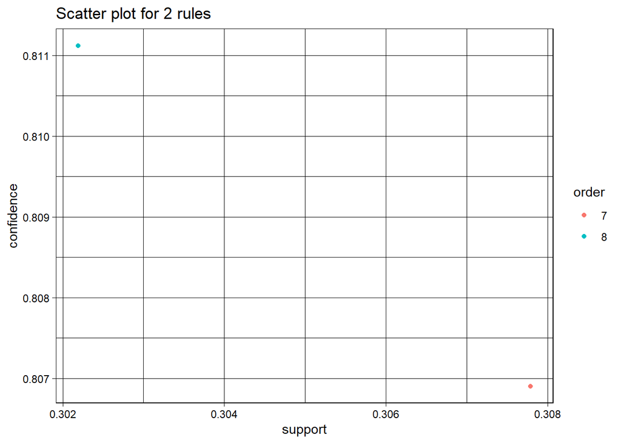

```r
plot(rules, method = "two-key plot")
```

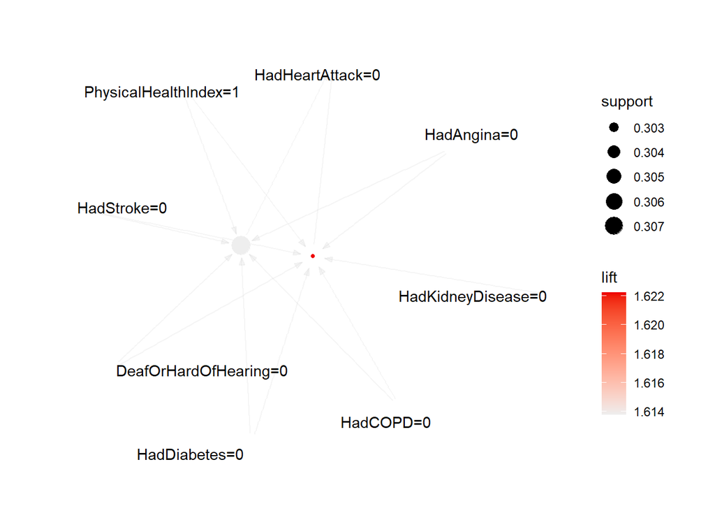

```r
plot(rules, method = "graph")
```

After extracting the best hyper-parameters and searching for association rules, we can observe that we haven’t managed to extract enough rules with sufficient confidence.

### Model results

Once we have all the models, we can compare them to see which one is the best:

```r
df_res <- data.frame(row.names = c("Name", "Accuracy", "Kap"))
for (result in model_results) {
  df_res <- rbind(
    df_res,
    data.frame(
      Name = result$name,
      Accuracy = result$metrics$accuracy,
      Kap = result$metrics$kap
    )
  )
}

df_res <- rbind(df_res, df_bayes)
df_res[order(-df_res$Accuracy, decreasing = FALSE), ]
```

```
##                Name  Accuracy       Kap
## 5              bart 0.8063203 0.6126406
## 6              mars 0.8018058 0.6036116
## 4       rand_forest 0.8000296 0.6000592
## 7                nn 0.7988455 0.5976909
## 8        boost_tree 0.7971433 0.5942866
## 1        logistical 0.7959591 0.5919183
## 9               lda 0.7918887 0.5837774
## 10      naive bayes 0.7801214 0.5602427
## 3     decision_tree 0.7781972 0.5563943
## 2  nearest_neighbor 0.7582889 0.5165779
```

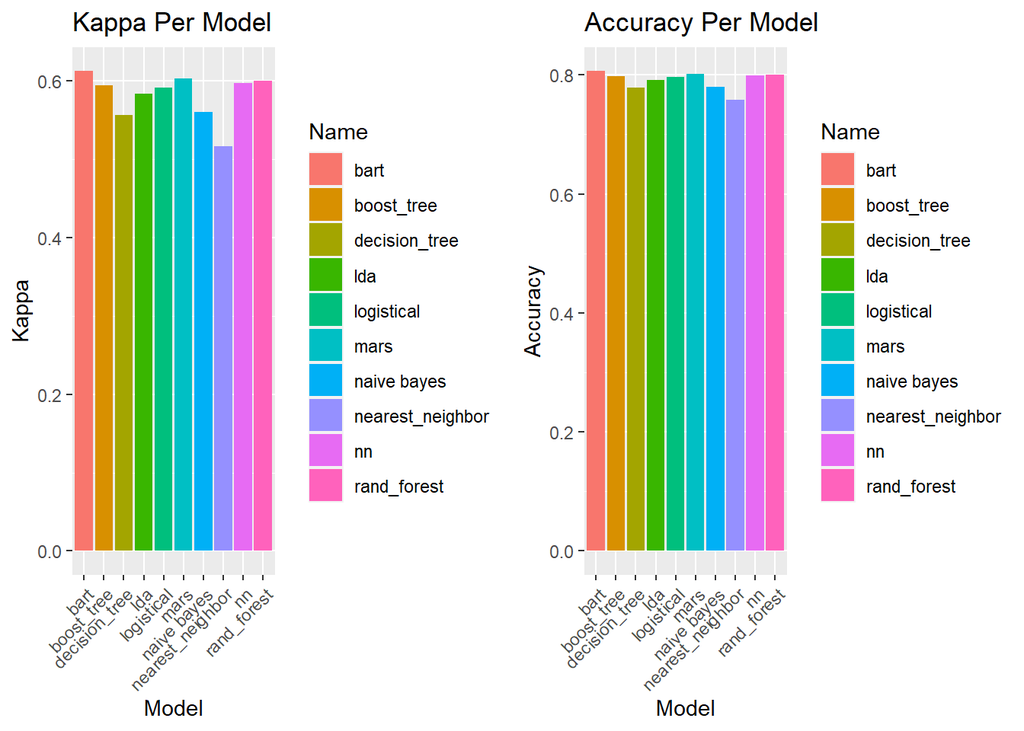

```r
grid.arrange(
  ggplot(df_res, aes(x = Name, y = Kap, fill = Name)) +
    geom_bar(stat = "identity") +
    labs(title = "Kappa Per Model", x = "Model", y = "Kappa") +
    theme(axis.text.x = element_text(angle = 45, hjust = 1)),
  ggplot(df_res, aes(x = Name, y = Accuracy, fill = Name)) +
    geom_bar(stat = "identity") +
    labs(title = "Accuracy Per Model", x = "Model", y = "Accuracy") +
    theme(axis.text.x = element_text(angle = 45, hjust = 1)),
  ncol = 2
)
```

### Model explanation

#### Decision tree

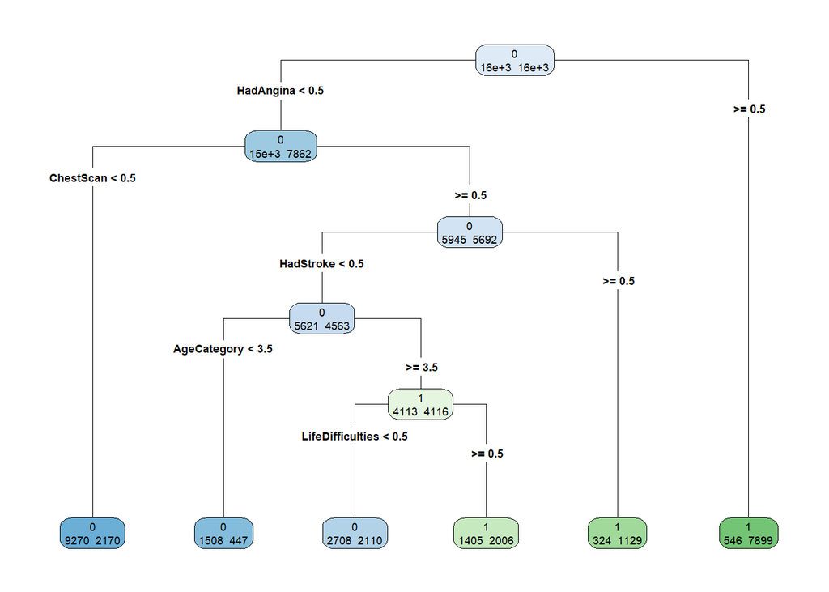

```r
rpart.plot(model_results[[3]]$model$fit, type = 4, extra = 1, roundint = FALSE)
```

Upon splitting the data using the decision tree, we can appreciate that the most important features are `HadAngina`, `ChestScan`, `AgeCategory`, `HadStroke`, and `LifeDifficulties`.

#### Random forest

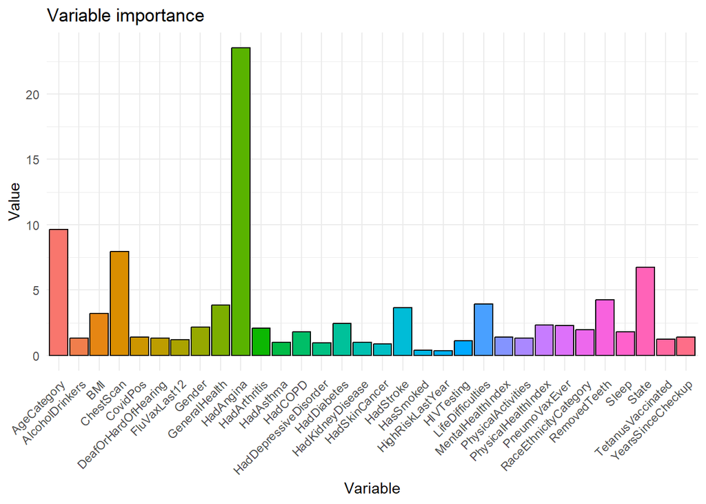

```r
tree <- model_results[[4]]$model$fit$variable.importance
importance <- (tree / sum(tree)) * 100

df_importancia <- data.frame(importance)

ggplot(df_importancia, aes(x = rownames(df_importancia), y = importance, fill = rownames(df_importancia))) +
  geom_bar(stat = "identity", color = "black") +
  labs(title = "Variable importance", x = "Variable", y = "Value") +
  theme_minimal() +
  theme(axis.text.x = element_text(angle = 45, hjust = 1), legend.position = "none")
```

As we can see, the most important variable is `HadAngina` with a big difference from the rest of the variables, nearly atoning to a 25% of overall importance.

#### XGBoost

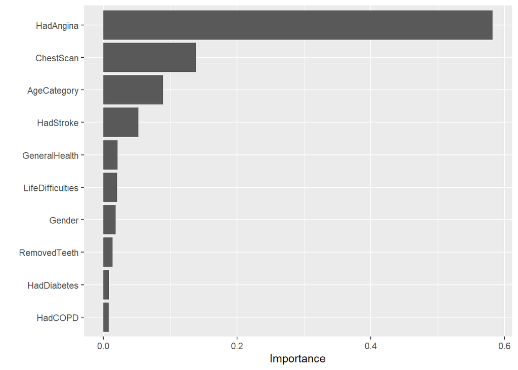

```r
vip(model_results[[8]]$model$fit)
```

In this model we can observe that the dominant variable is `hadAngina` with an impressive importance of 60% meanwhile the the second characteristic, `ChestScan`, is less than a 20%.

#### Naive Bayes

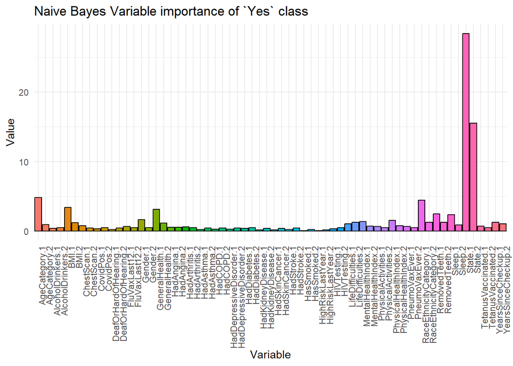

```r
freq <- t(data.frame(modelo_nb$tables))
colnames(freq)[colnames(freq) == "0"] <- "No"
colnames(freq)[colnames(freq) == "1"] <- "Yes"
freq <- data.frame(freq)

ggplot(freq, aes(x = rownames(freq), y = Yes, fill = rownames(freq))) +
  geom_bar(stat = "identity", color = "black") +
  labs(title = "Naive Bayes Variable importance of `Yes` class", x = "Variable", y = "Value") +
  theme_minimal() +
  theme(axis.text.x = element_text(angle = 90, hjust = 1), legend.position = "none")
```

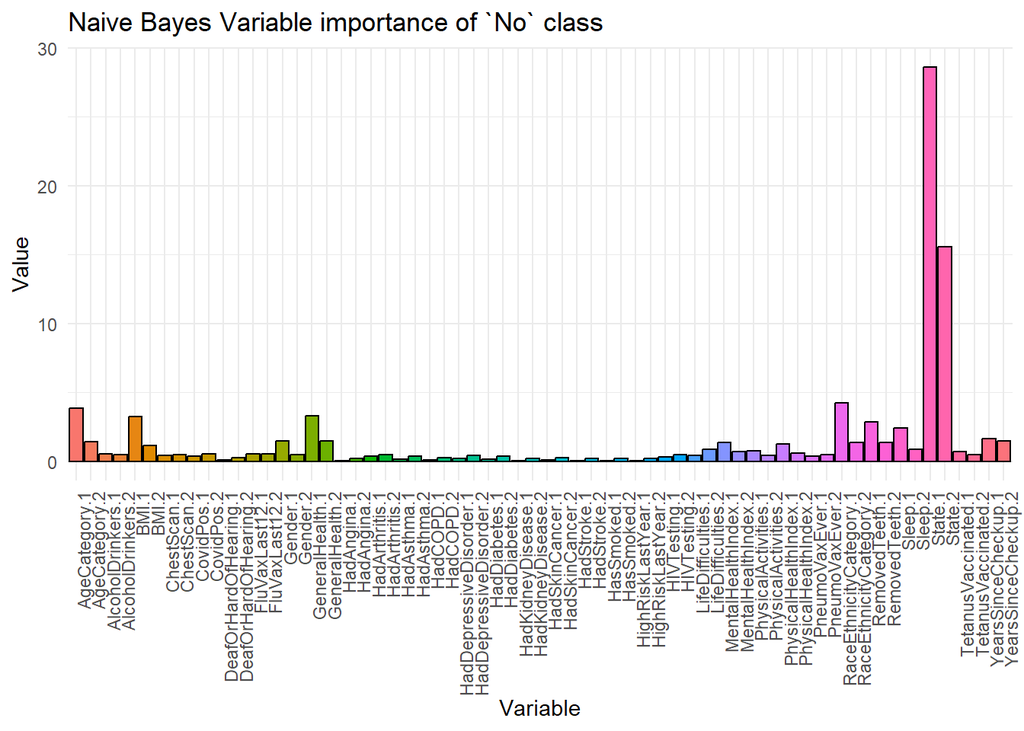

```r
ggplot(freq, aes(x = rownames(freq), y = No, fill = rownames(freq))) +
  geom_bar(stat = "identity", color = "black") +
  labs(title = "Naive Bayes Variable importance of `No` class", x = "Variable", y = "Value") +
  theme_minimal() +
  theme(axis.text.x = element_text(angle = 90, hjust = 1), legend.position = "none")
```

```r
coefs <- tidy(model_results[[1]]$model, conf.int = TRUE)
```

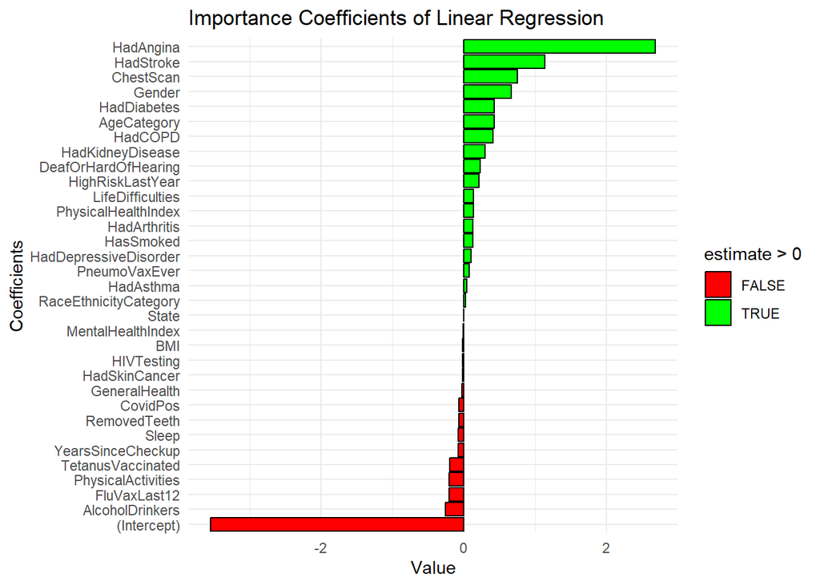

```r
ggplot(coefs, aes(x = reorder(term, estimate), y = estimate, fill = estimate > 0)) +
  geom_bar(stat = "identity", position = "identity", color = "black") +
  coord_flip() +
  labs(
    title = "Importance Coefficients of Linear Regression",
    x = "Coefficients",
    y = "Value"
  ) +
  scale_fill_manual(values = c("red", "green")) +
  theme_minimal()
```

#### MultiLayer Perceptron

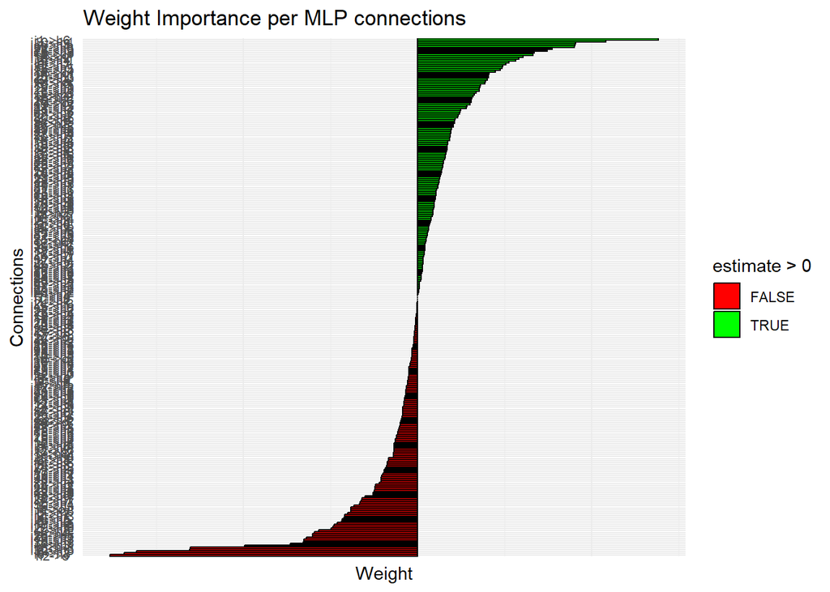

```r
coefs <- coef(model_results[[7]]$model$fit)
coefs_df <- data.frame(term = names(coefs), estimate = coefs)

ggplot(coefs_df, aes(x = reorder(term, estimate), y = estimate, fill = estimate > 0)) +
  geom_bar(stat = "identity", position = "identity", color = "black") +
  coord_flip() +
  labs(
    title = "Weight Importance per MLP connections",
    x = "Connections",
    y = "Weight"
  ) +
  scale_fill_manual(values = c("red", "green")) +
  theme_minimal() +
  theme(axis.text.y = element_text(size = 8, hjust = 0.5), axis.text.x = element_blank())
```

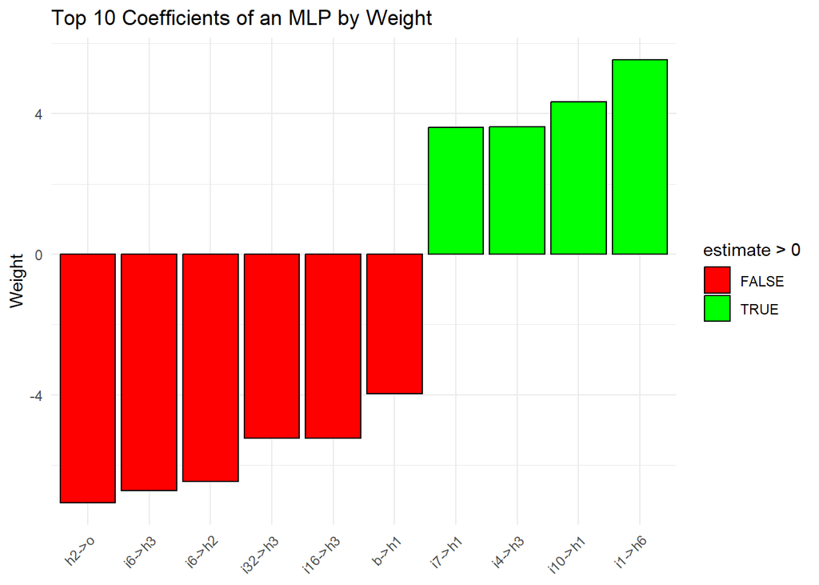

```r
top_coefs <- coefs_df %>%
  arrange(desc(abs(estimate))) %>%
  head(10)

ggplot(top_coefs, aes(x = reorder(term, estimate), y = estimate, fill = estimate > 0)) +
  geom_bar(stat = "identity", position = "identity", color = "black") +
  labs(
    title = "Top 10 Coefficients of an MLP by Weight",
    x = "Connections",
    y = "Weight"
  ) +
  scale_fill_manual(values = c("red", "green")) +
  theme_minimal() +
  theme(axis.text.x = element_text(angle = 45, hjust = 1, vjust = 1), axis.title.x = element_blank())
```

With the full connections of characteristics proved a difficult task to visualize correctly. As such, we filter significant characteristics to take the 10 most importants.

Even so, this model cannot be interpreted straightforwardly and the demanding nature of them proves a challenge out of bounds of this paper.